# Assignment 4 - Task 2

Samantha Kuglen

11/5/2021

### B. Data and Analysis

This juvenile snowshoe hare data was collected and made available by Dr. Knut Kielland and colleagues at the [Bonanza Creek Experimental Forest (US Long Term Ecological Research Site)](https://www.lter.uaf.edu/) in Bonanza Creek, Alaska. The data contain observations for relationships between weight, sex, and hindfoot length. Following exploratory data visualization, juvenile weights between male and female hares are compared by a two-sample t-test using a significance level of ($\alpha$) of 0.05. Differences between groups are described by by Cohen’s *d* effect size. The relationship between hindfoot length and weight between sex is explored by simple linear regression. All analyses are in R version 4.0.2 using RStudio version 1.3.1056.

**Data Citation:** Kielland, K., F.S. Chapin, R.W. Ruess, and Bonanza Creek LTER. 2017. Snowshoe hare physical data in Bonanza Creek Experimental Forest: 1999-Present ver 22. Environmental Data Initiative. https://doi.org/10.6073/pasta/03dce4856d79b91557d8e6ce2cbcdc14.

### C. Preliminary results

#### I: Data visualization of annual juvenile hare trap counts

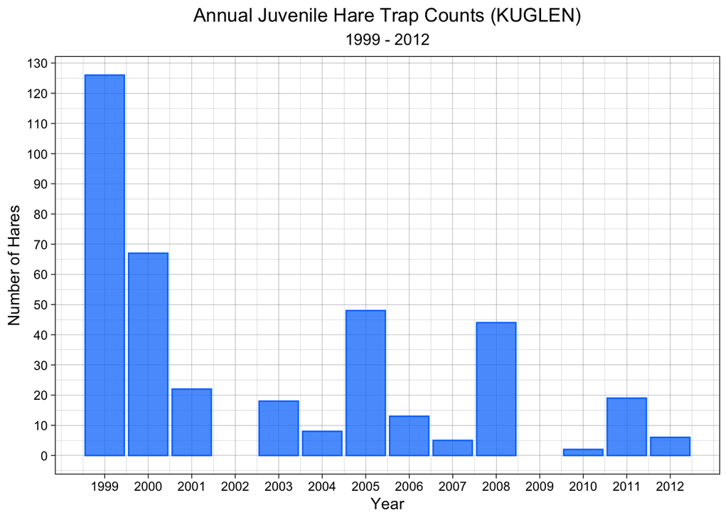

**Figure 1.** Histogram of annual juvenile hare trap counts in all sites at Bonanza Creek, Alaska from Kielland et al. (LTER. 2017).

Figure 1 shows the most observations of juvenile hares trapped, with a maximum count of 126. The years 2002 and 2009 demonstrate the minimum counts, where zero hares were observed. The annual mean count of hares trapped is 31.5 and the median count is 18.5. Notably, there is an overall decline from 1999 to 2012 in hare population with some fluctuations. For future analyses, observations among sites should be standardized among days, amount of traps, and measured distance of placement between traps. The raw data show that some years have more observations recorded than in other years and there is discrepancy in observations between sites. Consistency in time of year and number of observations would help to standardize the juvenile hare population data.

#### II: Juvenile weight comparison of male & female snowshoe hares

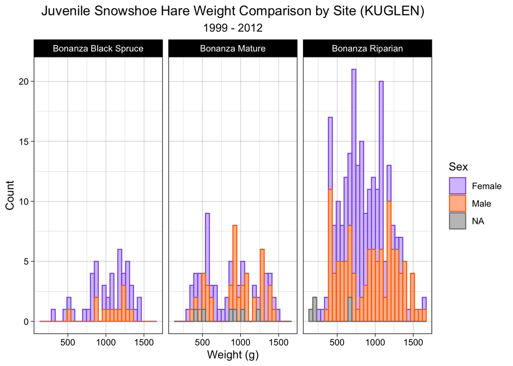

**Figure 2.** Snowshoe hare weight distribution by sex in Bonanza Creek, Alaska. Data: Kielland et al. LTER. 2017.

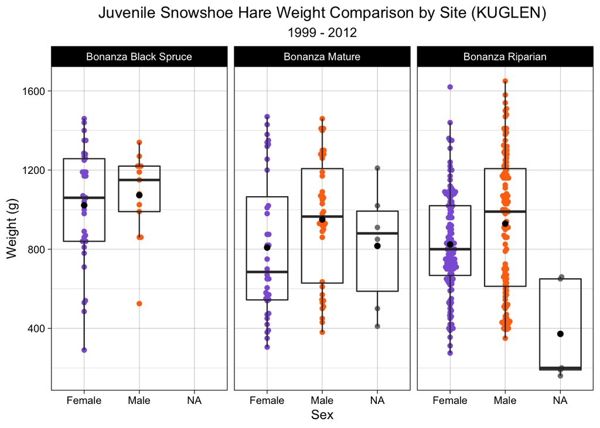

**Figure 3.** Box and whisker plot of snowshoe hare weight distribution by sex in Bonanza Creek, Alaska. Plots are separated out by trapping site at Bonanza Riparian, or Bonanza Mature, and Bonanza Black Spruce. Data: Kielland et al. LTER. 2017.

Figures 2 and 3 show that among sites, male juvenile hares have higher weights (in grams) than females. At the Bonanza Black Spruce site, differences in male and female juvenile hare weight are smaller than the other two trapping sites. There is not a significant difference in distribution of weights between the three sites. The Bonanza Riparian site has much more observations than the other two locations, while the Bonanza Black Spruce site has the lowest observations and the highest mean weights. The observed mean may be further from the true population mean at the Black Spruce site than at the Bonanza Riparian site, due to the lack of number of weights taken. More observations are needed for a representative comparison of the difference in population weights between sites.